# Explore consensus cell types

Ally Hawkins

2025-02-20

This notebook summarizes the findings from assigning consensus cell type labels to all ScPCA samples. All results from the `cell-type-consensus` module in `OpenScPCA-nf` must be saved to `results` prior to rendering this notebook.

```r
suppressPackageStartupMessages({
  # load required packages
  library(ggplot2)
})

# Set default ggplot theme
theme_set(
  theme_classic()
)
```

## Data setup

```r
# The base path for the OpenScPCA repository, found by its (hidden) .git directory
repository_base <- rprojroot::find_root(rprojroot::is_git_root)
module_base <- file.path(repository_base, "analyses", "cell-type-consensus")

# results directory with cell-type-consensus
results_dir <- file.path(module_base, "results", "cell-type-consensus")

# diagnoses table used for labeling plots
diagnoses_file <- file.path(module_base, "sample-info", "project-diagnoses.tsv")
```

```r
# list all results files
results_files <- list.files(results_dir, pattern = "_processed_consensus-cell-types\\.tsv.\\gz$", recursive = TRUE, full.names = TRUE)

# define cell line projects to remove
cell_line_projects <- c("SCPCP000020", "SCPCP000024")
```

```r
# source summarize_celltypes() function
setup_functions <- file.path(module_base, "exploratory-notebooks", "utils", "setup-functions.R")
source(setup_functions)
```

```r
# read in diagnoses
diagnoses_df <- readr::read_tsv(diagnoses_file)


# read in results and prep data frame for plotting
all_results_df <- results_files |>
  purrr::imap(summarize_celltypes) |>
  dplyr::bind_rows() |>
  # remove cell line projects
  dplyr::filter(!project_id %in% cell_line_projects) |>
  # add in diagnoses
  dplyr::left_join(diagnoses_df, by = "project_id") |>
  dplyr::mutate(
    # create a label for plotting
    project_label = glue::glue("{project_id}:{diagnosis}")
  )
```

## Is it all just Unknown?

The first thing we will look at is how many of the cells in each sample are categorized as “Unknown”, which means no consensus between `SingleR` and `CellAssign` was identified.

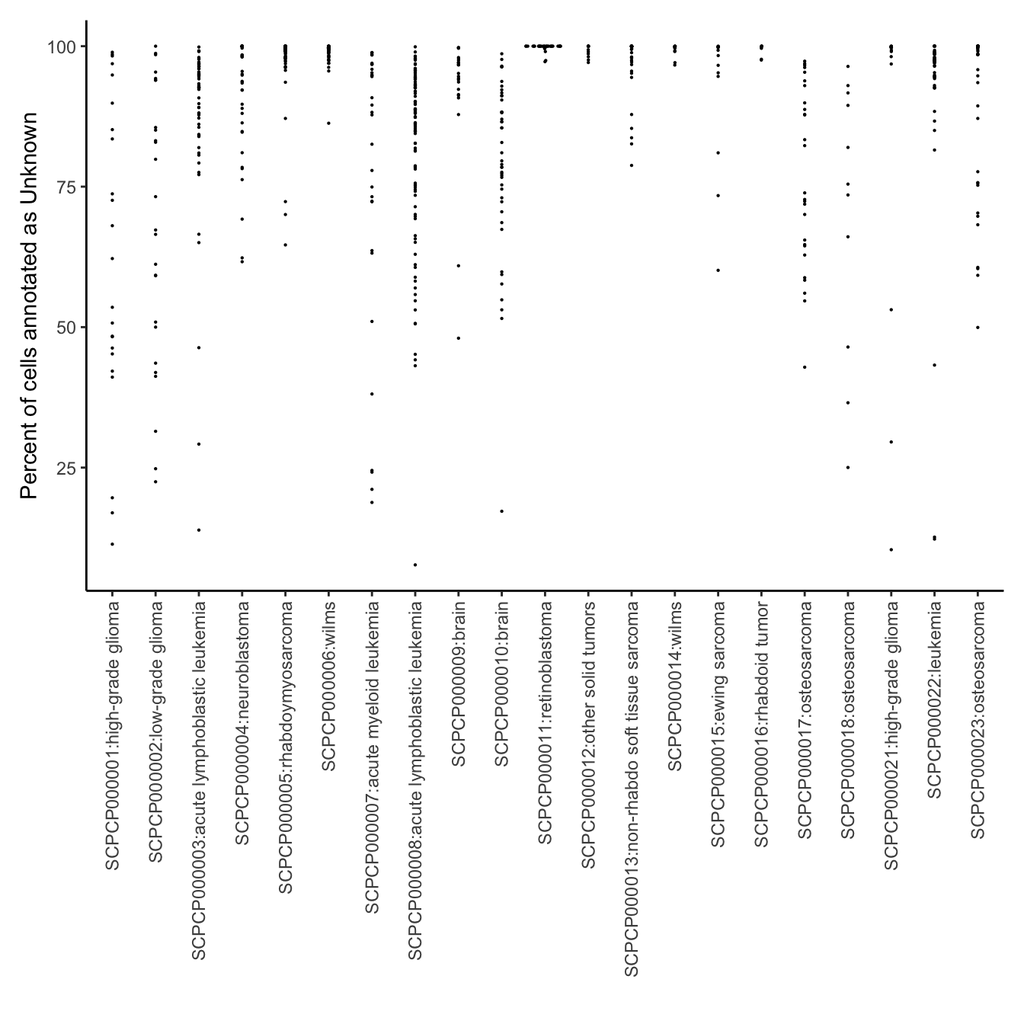

```r
unknown_only <- all_results_df |>
  dplyr::filter(consensus_annotation == "Unknown")

ggplot(unknown_only, aes(x = project_label, y = percent_cells_annotation)) +
  ggforce::geom_sina(size = 0.1) +
  theme(axis.text.x = element_text(angle = 90, hjust = 1, vjust = 0.5),
        plot.margin = margin(10,10,10,10)) +
  labs(
    x = "",
    y = "Percent of cells annotated as Unknown"
  )
```

It looks like we do have some samples that aren’t just all “Unknown”! It definitely varies by project, but for most projects we at least see some proportion of samples with assigned cell types.

Let’s look at how many samples actually have some cells outside of unknown identified. To do this, we will identify all libraries that only have cells called as “Unknown”.

```r
high_tumor_df <- unknown_only |>
  dplyr::mutate(no_cells_identified = percent_cells_annotation == 100) |>
  dplyr::group_by(project_label) |>
  dplyr::summarize(all_unknown = sum(no_cells_identified),
                   classified_cells = sum(!no_cells_identified),
                   percentage_unknown = round(all_unknown/(all_unknown + classified_cells)*100, 2),
                   # add number of libraries for plotting
                   total_libraries = length(library_id)) |>
  # set order for plots
  dplyr::mutate(project_label = forcats::fct_reorder(project_label, total_libraries, .desc = TRUE))
```

Which projects have the highest proportion of samples with all “Unknown”?

```r
# table with percentage of samples
high_tumor_df |>
  dplyr::select(project_label, percentage_unknown) |>
  dplyr::arrange(desc(percentage_unknown))
```

| project_label | percentage_unknown |
| --- | --- |
| SCPCP000011:retinoblastoma | 63.89 |
| SCPCP000016:rhabdoid tumor | 42.86 |
| SCPCP000012:other solid tumors | 36.36 |
| SCPCP000023:osteosarcoma | 34.62 |
| SCPCP000013:non-rhabdo soft tissue sarcoma | 24.24 |
| SCPCP000004:neuroblastoma | 21.43 |
| SCPCP000014:wilms | 20.00 |
| SCPCP000022:leukemia | 16.00 |
| SCPCP000021:high-grade glioma | 13.33 |
| SCPCP000005:rhabdoymyosarcoma | 13.11 |

[output cut: 11 more lines]

It looks like all projects do have cell types identified that are not “Unknown”. However, `SCPCP000011` (retinoblastoma), has a fairly high percentage of samples without any consensus labels.

Let’s also look at the projects that have PDX samples. I expect that fewer cells are able to be classified in PDX samples compared to their patient tissue counterparts.

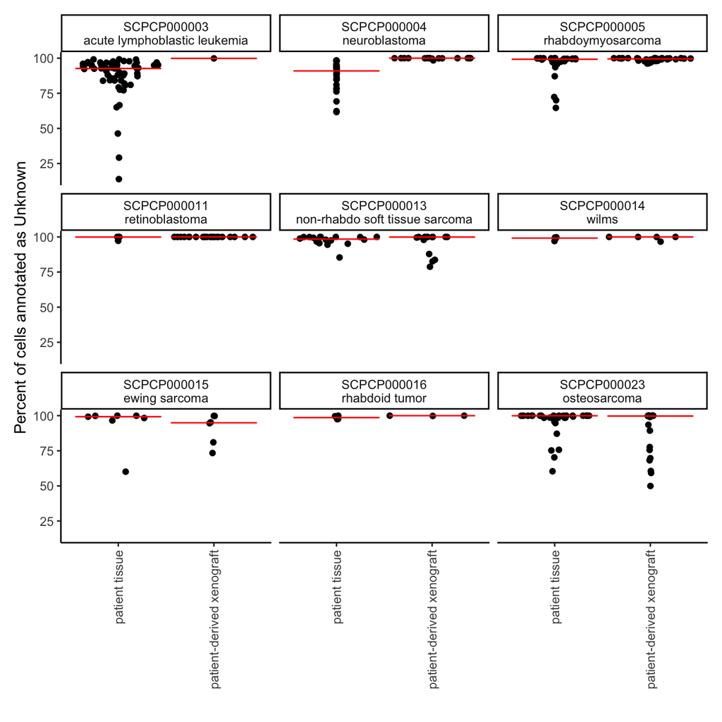

```r
# list of projects with pdx
pdx_projects <- c(
  "SCPCP000003",
  "SCPCP000004",
  "SCPCP000005",
  "SCPCP000011",
  "SCPCP000013",
  "SCPCP000014",
  "SCPCP000015",
  "SCPCP000016",
  "SCPCP000023"
)

# filter to pdx projects and adjust the facet label
pdx_only <- unknown_only |>
  dplyr::filter(project_id %in% pdx_projects) |>
  dplyr::mutate(facet_label = glue::glue("{project_id}\n{diagnosis}"))

# faceted sina showing patient tissue vs. pdx
ggplot(pdx_only, aes(x = sample_type, y = percent_cells_annotation)) +
  ggforce::geom_sina() +
  stat_summary(fun.y=median, geom="crossbar" , color = "red", linewidth = 0.2) +
  facet_wrap(vars(facet_label)) +
  theme(axis.text.x = element_text(angle = 90, hjust = 1, vjust = 0.5),
        plot.margin = margin(10,10,10,10)) +
  labs(
    x = "",
    y = "Percent of cells annotated as Unknown"
  )
```

It looks like in `SCPCP000003` and `SCPCP000004` the PDX samples have less cells classified than the patient tissue samples.

For `SCPCP000015` there may be a higher percentage of cells that are classified in a few of the PDX samples. For `SCPCP000023` and `SCPCP000013` there appears to be a handful of PDX and patient tissue samples that have cells that are classified with no real difference between the two sample types. My hunch is that the cells getting classified in `SCPCP000013`, `SCPCP000015`, and `SCPCP000023` PDX samples are muscle cells which are very similar to the tumor cells.

For the remaining projects, there are very few samples that have any cells classified regardless of sample type.

## Number of cell types observed

Below we look at the number of cell types observed in each project for all samples. This does not include cells labeled as “Unknown”.

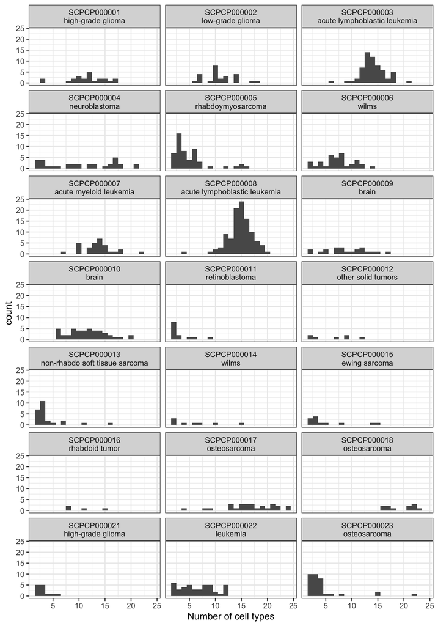

```r
num_celltypes_df <- all_results_df |>
  # add a new line for facet labels
  dplyr::mutate(facet_label = glue::glue("{project_id}\n{diagnosis}")) |>
  # remove unknown as a cell type
  dplyr::filter(consensus_annotation != "Unknown") |>
  dplyr::select(facet_label, library_id, num_celltypes) |>
  unique()

ggplot(num_celltypes_df, aes(x = num_celltypes)) +
  geom_histogram(binwidth = 1, center = 0) +
  facet_wrap(vars(facet_label),
             ncol = 3) +
  labs(
    x = "Number of cell types"
  ) +
  theme_bw()
```

## Distribution of consensus cell types

Now we look at the distribution of the cell types in each sample. For these plots, we will pull out the top 9 cell types for each project. All other cells will be labeled with “All remaining cell types”.

The top cell types are determined by counting how many libraries each cell type is found in within a project and taking the most frequent types.

```r
plot_df <- all_results_df |>
    dplyr::group_by(project_id) |>
    dplyr::mutate(
      # get most frequently observed cell types across libraries in that project
      top_celltypes = forcats::fct_lump_n(consensus_annotation, 9, other_level = "All remaining cell types", ties.method = "first") |>
        # sort by frequency
        forcats::fct_infreq() |>
        # make sure all remaining and unknown are last, use this to assign colors in specific order
        forcats::fct_relevel("All remaining cell types", "Unknown", after = Inf)
    )

# get all unique cell types ordered by frequency
unique_celltypes <- plot_df |>
  dplyr::filter(!top_celltypes %in% c("All remaining cell types", "Unknown")) |>
  dplyr::pull(top_celltypes) |>
  unique() |>
  sort() |>
  as.character()

# get color palette
colors <- c(
  palette.colors(palette = "alphabet"),
  "lightyellow", # plasma cell
  "black", # glial cell
  "grey60",
  "grey95"
)
names(colors) <- c(unique_celltypes, "All remaining cell types", "Unknown")
```

[figure not shown]

```r
project_labels <- unique(all_results_df$project_label)

# stacked bar chart showing the distribution of the top 9 cell types for each project, including Unknown
project_labels |>
  purrr::map(\(label){

    project_df <- plot_df |>
      dplyr::filter(project_label == label) |>
      dplyr::mutate(
        # relevel factors for specific project
        top_celltypes = forcats::fct_infreq(top_celltypes) |>
          forcats::fct_relevel("All remaining cell types", "Unknown", after = Inf)
      )

    # make a stacked bar chart with top cell types
    ggplot(project_df) +
      aes(
        x = library_id,
        y = percent_cells_annotation,
        fill = top_celltypes
      ) +
      geom_col() +
      # split samples based on sample type, patient tissue or pdx
      facet_wrap(vars(sample_type), scales ="free") +
      scale_y_continuous(expand = c(0,0)) +
      scale_fill_manual(values = colors, name = "cell type") +
      ggtitle(label) +
      theme(axis.text.x = element_blank())

    }) |>
  patchwork::wrap_plots(ncol = 1)
```

This looks really promising! A few observations:

- Cell types identified tend to line up with expectations for the type of tumor. For example, leukemia libraries have T and B cells, brain tumors have macrophages, and solid tumors have fibroblasts and muscle cells.
- Projects that I would expect to be more difficult to classify (sarcomas, Wilms, RB) have fewer cells classified then things like brain and leukemia.
- Generally there are very few cells classified in the PDX samples, and if they are classified they tend to be muscle cell types, fibroblasts, and in a handful of cases, endothelial cells. Immune cell types appear to be absent. Notably the projects that have PDX samples are solid tumors and sarcoma projects, where muscle cells or fibroblasts can be similar to tumor cells.
- `SCPCP000023` seems to be an exception where a good amount of PDX samples have a high percentage of classified cells, although they are either muscle cells or chondrocytes. My guess is that these cells look very similar to tumor cells, which is why they are being classified.

It’s important to note that when we quantify gene expression using `alevin-fry` in `scpca-nf` we only use a human reference, so I would not expect non-malignant cells to appear in the PDX samples at any high frequency. Because of this, I think it may be safest to remove these samples when conducting any further analysis.

## Most frequently observed cell types

The last thing we will do is look at the most frequently observed cell types across all samples. The below table is ordered by the number of libraries the cell type is observed.

```r
all_results_df |>
  dplyr::filter(consensus_annotation != "Unknown") |>
  dplyr::group_by(consensus_annotation) |>
  dplyr::summarize(
    total_libraries = dplyr::n(),
    min_percentage = min(percent_cells_annotation),
    mean_percentage = round(mean(percent_cells_annotation), 2),
    median_percentage = median(percent_cells_annotation),
    max_percentage = max(percent_cells_annotation)
  ) |>
  dplyr::arrange(desc(total_libraries))
```

| consensus_annotation | total_libraries | min_percentage | mean_percentage | median_percentage | max_percentage |
| --- | --- | --- | --- | --- | --- |
| mature T cell | 411 | 0.00 | 1.37 | 0.440 | 21.06 |
| natural killer cell | 353 | 0.01 | 0.71 | 0.280 | 15.62 |
| T cell | 350 | 0.01 | 2.16 | 0.920 | 34.67 |
| monocyte | 344 | 0.01 | 1.44 | 0.240 | 35.16 |
| memory T cell | 309 | 0.00 | 0.86 | 0.100 | 32.51 |
| mononuclear phagocyte | 287 | 0.01 | 1.46 | 0.100 | 73.44 |
| lymphocyte of B lineage | 286 | 0.00 | 1.44 | 0.200 | 45.92 |
| macrophage | 262 | 0.00 | 6.12 | 0.880 | 81.62 |
| naive B cell | 251 | 0.00 | 0.90 | 0.250 | 44.51 |
| myeloid leukocyte | 250 | 0.01 | 0.81 | 0.090 | 34.18 |

[output cut: 35 more lines]